# Apprentissage Statistique - Compte rendu du TP2

*Par Alexandre COMBESSIE et Saad MACHRAOUI*

### 1. Expliquer la commande `apply(cvpred,2,function(x) sum(class!=x))`

L’erreur globale, qui correspond au resultat de cette commande, peut êre alors définie comme un vecteur de nombre des erreurs commises sur le nombre total des échantillons de test pour k= 1,2 …10. L’estimation consiste en une classification au sein de trois classes (“setosa”,“versicolor”,“virginica”). L’erreur de classification est booléenne (`class!=x` soit 0 soit 1). On peut l’écrire mathématiquement comme suit: $e=\frac{1}{n}\sum_{i=1}^{n} \mathbb{I}_(y_{pred}\neq y)$

### 2. Pourquoi si l’on relance deux fois les commandes de la page 2, les résultats obtenus ne sont pas les mêmes ? Imaginons que nous avons lancé ces commandes 100 fois. Proposez une stratégie pour choisir k en combinant ces 100 résultats obtenus.

En relançant deux fois la commande on obtient différents résultats parce que l’algorithme utlisé se base sur un choix d’echantillons et ce choix se fait de façon aléatoire. A chaque éxecution on a un vecteur `fold` différent ce qui résulte de deux échantillons `sample1` et `sample2` différents à chaque exécution. En éxecutant la commande 100 fois, on peut mettre une place la stratégie suivante: - on stocke dans une matrice (100x10) les erreurs de classification obtenues - on calcule la moyenne des colonnes pour chaque k=1,2… 10 - notre “k” optimal correspondera à l’indice du vecteur contenant le minimum des moyennes calculées.

```r
fold = sample(rep(1:5,each=18)) # creation des groupes B_v
cvpred = matrix(NA,nrow=90,ncol=10) # initialisation de la matrice
# des predicteurs
error = matrix(NA,nrow=100,ncol=10)
error_mean = c()
for (i in 1:100)  {
  for (k in 1:10) {
    for (v in 1:5)  {
        sample1 = train[which(fold!=v),1:4]
        sample2 = train[which(fold==v),1:4]
        class1 = train[which(fold!=v),5]
        cvpred[which(fold==v),k] = knn(sample1,sample2,class1,k=k)}}
  class = as.numeric(train[,5])
  error[i,]=apply(cvpred,2,function(x) sum(class!=x))}
for (i in 1:10) {
  error_mean[i]=mean(error[,i])}
k_optimal = which(error_mean==min(error_mean))
```

### 3. Répondre aux questions 1-5 ci-dessus en insérant le code le cas échéant.

#### 3.1. Ecrire un code qui permet d’ajouter aux chandeliers japonais la courbe des valeurs médianes. Que se passe-t-il si l’on supprime l’argument `on=1` de la fonction `addAvgPrice` ?

On peut ajouter aux chandeliers japonais la courbe des valeurs médianes de la même facon qu’on ajoute la courbe des valeurs moyennes, en définissant une fonction `MedPrice` qui retourne la médiane des valeurs et une fonction `addMedPrice` pour l’ajouter au graphique. Si on supprime l’option `on=1` les courbes supplémentaires `TA` ne sont pas superposées sur le même graphique mais ajoutées sur un graphique séparé en dessous. Cela donne par exemple:

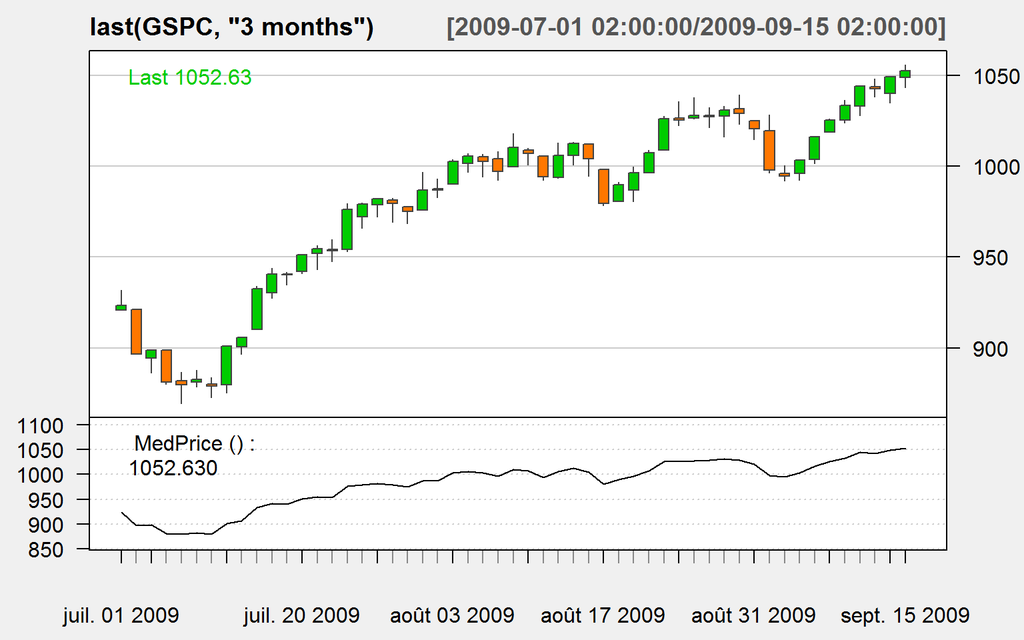

```r
MedPrice = function(p) apply(HLC(p), 1, median)
addMedPrice=newTA(FUN = MedPrice, col = 1, legend = "MedPrice")
candleChart(last(GSPC,"3 months"), theme = "white", TA = "addMedPrice()")
```

#### 3.2 A quoi l’option `training.per` de la fonction `buildModel` correspond-t-elle ? et l’option `importance` ?

L’option `training.per` indique à la fonction `buildModel` où commence et où s’arrête l’échantillon d’entraînement en termes de dates. On note que comme ce sont des données de séries temporelles, il faut absolument que ce soit une plage temporelle continue. Il n’est pas possible de sélectionner un échantillon d’entraînement aléatoire comme on peut le faire sur d’autres types de données en Machine Learning.

Quant à l’option binaire `importance`, il s’agit de savoir si oui/non on demande au modèle `randomForest` d’étudier l’importance des variables/prédicteurs. C’est une mesure intéressante en termes d’interprétation des variables pour voir lesquelles sont “importantes” pour prédire. Si l’option est choisie, soit `importance=T`, on peut extraire cette information du modèle directement:

```r
head(rf@fitted.model$importance,5)
```

```
##                                           %IncMSE IncNodePurity
## Delt.Cl.GSPC.k.1.10.Delt.1.arithmetic 0.006279277      8.116382
## Delt.Cl.GSPC.k.1.10.Delt.2.arithmetic 0.004729863      6.625244
## Delt.Cl.GSPC.k.1.10.Delt.3.arithmetic 0.003644490      4.964690
## Delt.Cl.GSPC.k.1.10.Delt.4.arithmetic 0.004029836      5.395806
## Delt.Cl.GSPC.k.1.10.Delt.5.arithmetic 0.004732197      5.563437
```

On remarque que cette option augmente le temps de calcul du modèle. Sur une simulation, le temps de calcul sans l’option `importance` est de 27 secondes, à comparer à 35 secondes avec l’option.

```r
t1<-system.time(buildModel(data.model,method="randomForest",
          training.per=c(start(GSPC),index(GSPC["1999-12-31"])),ntree=50, importance=T))[3]
#print(paste("Temps de calcul avec importance: ",toString(round(t1,0))," secondes"))
t2<-system.time(buildModel(data.model,method="randomForest",
          training.per=c(start(GSPC),index(GSPC["1999-12-31"])),ntree=50, importance=F))[3]
#print(paste("Temps de calcul sans importance: ",toString(round(t2,0))," secondes"))
```

#### 3.3 Sachant que le graphique tracé représente le pourcentage d’augmentation de l’erreur quadratique due à la suppression d’une variable explicative, déterminer les 8 variables les plus pertinentes.

La fonction `varImpPlot` va trier par défaut les variables par ordre d’importance décroissant (`sort=TRUE`), les plus importantes étant en haut du graphique. Ici l’importance est vue comme le pourcentage d’augmentation de l’erreur quadratique due à la suppression de la variable. Cela correspond à l’option `type=1`. On aurait pu prendre `type=2` auquel cas l’importance serait vue comme la baisse des “node impurities” induite par un split sur la variable, moyenné sur tous les arbres.

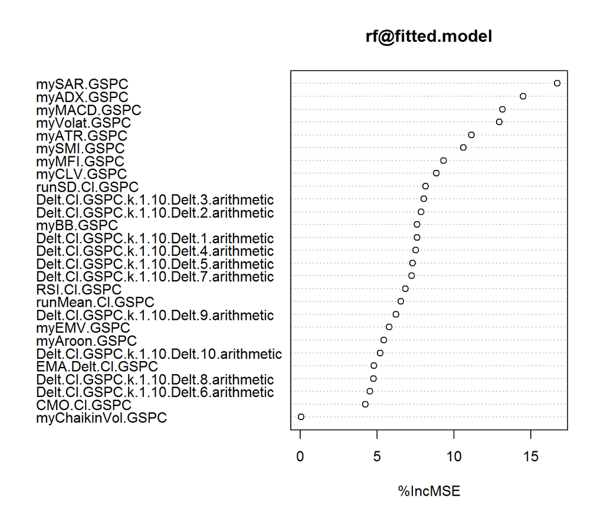

Les 8 variables les plus “pertinentes” sont donc les 8 premières en haut du graphique, soit:

```
1. SAR : Parabolic Stop-and-Reverse Index
2. ADX : Welles Wilder's Directional Movement Index
3. MACD : Moving Average Convergence/Divergence oscillator
4. Volat : Volatility indicator
5. ATR : Average True Range
6. SMI : Stochastic Momentum Index
7. MFI : Money Flow Index
8. CLV : Close Location Value
```

#### 3.4 En utilisant la fonction `specifyModel`, définir le nouveau modèle `data.model` qui a pour variable à expliquer `T.ind(GSPC)` et comme variables explicatives les 8 variables les plus pertinentes trouvées dans la question précédente.

Il suffit d’utiliser la fonction `specifyModel` en lui passant comme argument `Variable à expliquer ~ Variables explicatives choisies`.

```r
Variables_explicatives<-c("SAR","ADX","MACD","Volat","ATR","SMI","MFI","CLV")
Variables_explicatives2<-sapply(Variables_explicatives,
                                FUN=function(x){paste("my",x,"(GSPC)",sep="")})
formula<-as.formula(paste("T.ind(GSPC) ~ ",paste(Variables_explicatives2, collapse= "+")))
data.model2 <- specifyModel(formula)
```

#### 3.5 Que fait la fonction `na.omit`? Pourquoi son utilisation est plus importante (voire indispensable) dans la définition de l’échantillon de test, alors que l’on s’en passe dans la définition de l’échantillon d’entrainement.

```r
Tdata.train = as.data.frame(modelData(
  data.model,data.window=c("1970-01-02","1999-12-31")))
Tdata.eval = na.omit(as.data.frame(modelData(
  data.model,data.window=c("2000-01-01","2009-09-15"))))
```

La fonction `na.omit` est indispensable dans la définition de l’échantillon de test, car cet échantillon sert à l’évaluation de la performance du modèle. Les valeurs manquantes empêcheraient la bonne mesure de la performance, ou fausseraient son évaluation. En revanche, pour la définition de l’échantillon d’entraînement, cela n’est pas nécessaire car on est pas au stade de l’évaluation.

### 4. Utiliser l’algorithme *kNN* pour prédire la variable signal sur l’échantillon de test `Tdata.eval`, en utilisant `Tdata.train` comme échantillon d’entraînement. Evaluer l’erreur de la prédiction.

On utilisera ici l’algorithme `knn` pour prédire la variable signal en suivant les memes etapes que la premiere question.Pour evaluer l’erreur de la prediction, on utilise la meme commande utilisee et expliquee dans la premiere question `apply(cvpred,2,function(x) sum(class!=x))` et on stockera le resultat dans le vecteur `errors_knn`.

### 4. Utiliser l’algorithme *kNN* pour prédire la variable signal sur l’échantillon de test `Tdata.eval`, en utilisant `Tdata.train` comme échantillon d’entraînement. Evaluer l’erreur de la prédiction. Inclure le code.

On utilisera ici l’algorithme `knn` pour prédire la variable signal en suivant les memes etapes que la premiere question.Pour evaluer l’erreur de la prediction, on utilise la meme commande utilisee et expliquee dans la premiere question `apply(cvpred,2,function(x) sum(class!=x))` et on stockera le resultat dans le vecteur `errors_knn`. Dans notre cas, on obtient pour k=10 la plus petite erreur de prediction.

```r
Tdata.eval[,1] = trading.signals(Tdata.eval[,1],0.1,-0.1)
Tdata.train[,1] = trading.signals(Tdata.train[,1],0.1,-0.1)
names(Tdata.eval)[1] = "signal"
names(Tdata.train)[1] = "signal"
#summary(Tdata.train) #Mis en commentaire pour limiter la taille du compte rendu
#summary(Tdata.train) #Mis en commentaire pour limiter la taille du Compte Rendu

cvpred = matrix(NA,nrow=2430,ncol=10)  #Pour le recueil des résultats;
class=as.numeric(Tdata.eval[,1])       #Vraies classes de Tdata.eval;

cvpred = matrix(NA,nrow=2430,ncol=10)
class=as.numeric(Tdata.eval[,1])
for(i in (1:10))  {
  cvpred[,i] = knn(Tdata.train[,-1], Tdata.eval[,-1] , Tdata.train[,1], k = i)}
errors_knn = apply(cvpred,2,function(x) sum(class!=x))
errors_knn
```

```
##  [1] 1363 1347 1336 1308 1280 1283 1294 1273 1205 1162
```

```r
# Matrice de confusion de l'indice k correspondant au minimum d'erreurs:
table(cvpred[,which(errors_knn==min(errors_knn))],Tdata.eval[,1])
```

```
##
##        s    h    b
##   1   86  242   41
##   2  267 1116  242
##   3   85  285   66
```

### 5. La même chose pour l’algorithme d’arbre de décision. Est-il meilleur que kNN ? Afficher l’arbre de décision obtenu.

En comparant la matrice de confusion obtenue à la question 4 et la matrice de confusion ci dessous, on remarque que l’erreur de prediction pour l’arbre de decision est inferieure à l’erreur de prediction pour l’algorithme knn, on en conclut que l’algorithme d’arbre de decision est meilleur que knn au sens de l’erreur de classification sur notre échantillon.

```r
library(rpart)
Tdata.train[,1]=as.data.frame(modelData(data.model,
                                     data.window=c("1970-01-02","1999-12-31")))[,1]
Tdata.eval[,1]=na.omit(as.data.frame(modelData(data.model,
                                           data.window=c("2000-01-01","2009-09-15"))))[,1]
regressionFormula = "signal ~ myATR.GSPC + mySMI.GSPC + myADX.GSPC + myCLV.GSPC +
                            myVolat.GSPC + myMACD.GSPC + myMFI.GSPC +mySAR.GSPC"
importantVars = c("myATR.GSPC","mySMI.GSPC","myADX.GSPC",
                  "myCLV.GSPC","myVolat.GSPC","myMACD.GSPC",
                  "myMFI.GSPC","mySAR.GSPC")
importantColumnsIndexes = c(1)
i=2
for(var in importantVars)  {
  importantColumnsIndexes[i] = which(colnames(Tdata.train) == var)
  i= i+1
  }
rt.ai = rpart(regressionFormula, data = Tdata.train[,importantColumnsIndexes])
rt.predictions.eval = predict(rt.ai, Tdata.eval[,-1])
predictions.eval.signal = trading.signals(rt.predictions.eval ,0.1,-0.1)
table(predictions.eval.signal,trading.signals(Tdata.eval[,1],0.1,-0.1))
```

```
##
## predictions.eval.signal    s    h    b
##                       s    0    0    0
##                       h  366 1575  267
##                       b   72   68   82
```

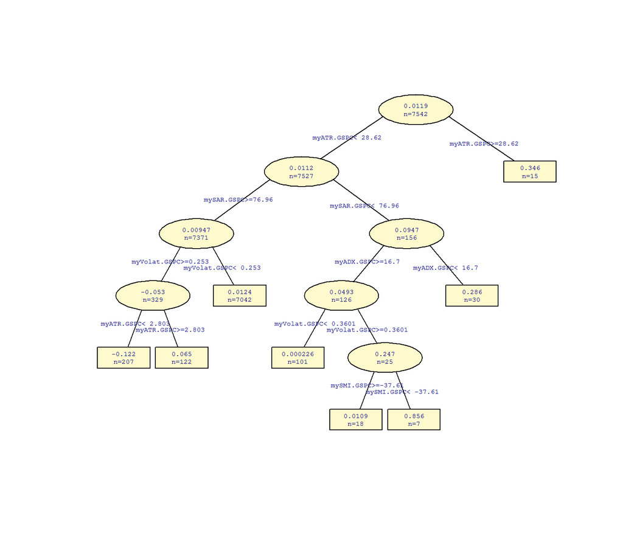

```r
prettyTree(rt.ai,col="navy",bg="lemonchiffon",cex=0.5)
```

# Annexes

## I. Predicteur KNN

```r
library(class)
data(iris)
head(iris)
```

```
##   Sepal.Length Sepal.Width Petal.Length Petal.Width Species
## 1          5.1         3.5          1.4         0.2  setosa
## 2          4.9         3.0          1.4         0.2  setosa
## 3          4.7         3.2          1.3         0.2  setosa
## 4          4.6         3.1          1.5         0.2  setosa
## 5          5.0         3.6          1.4         0.2  setosa
## 6          5.4         3.9          1.7         0.4  setosa
```

```r
summary(iris)
```

```
##   Sepal.Length    Sepal.Width     Petal.Length    Petal.Width
##  Min.   :4.300   Min.   :2.000   Min.   :1.000   Min.   :0.100
##  1st Qu.:5.100   1st Qu.:2.800   1st Qu.:1.600   1st Qu.:0.300
##  Median :5.800   Median :3.000   Median :4.350   Median :1.300
##  Mean   :5.843   Mean   :3.057   Mean   :3.758   Mean   :1.199
##  3rd Qu.:6.400   3rd Qu.:3.300   3rd Qu.:5.100   3rd Qu.:1.800
##  Max.   :7.900   Max.   :4.400   Max.   :6.900   Max.   :2.500
##        Species
##  setosa    :50
##  versicolor:50
##  virginica :50
##
##
##
```

```r
train = iris[c(1:30,51:80,101:130),1:5]
test = iris[c(31:50,81:100,131:150),1:5]

pred = knn(train[,1:4], test[,1:4], train[,5], k = 3)
# display the confusion matrix
table(pred,test[,5])
```

```
##
## pred         setosa versicolor virginica
##   setosa         20          0         0
##   versicolor      0         19         0
##   virginica       0          1        20
```

```r
# 5-fold cross-validation to select k
# from the set {1,...,10}
fold = sample(rep(1:5,each=18)) # creation des groupes B_v
cvpred = matrix(NA,nrow=90,ncol=10) # initialisation de la matrice
# des predicteurs
for (k in 1:10)
    for (v in 1:5)  {
        sample1 = train[which(fold!=v),1:4]
        sample2 = train[which(fold==v),1:4]
        class1 = train[which(fold!=v),5]
        cvpred[which(fold==v),k] = knn(sample1,sample2,class1,k=k)}
class = as.numeric(train[,5])
# display misclassification rates for k=1:10
apply(cvpred,2,function(x) sum(class!=x)) # calcule l'erreur de classification
```

```
##  [1] 7 7 6 6 5 4 3 5 5 5
```

## II.Predicting stock market returns

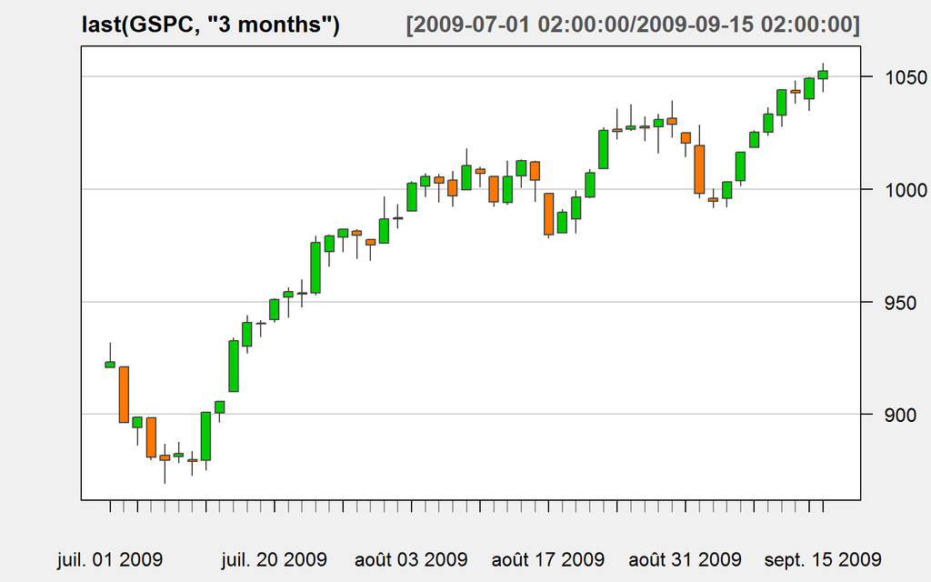

```r
library(DMwR)
data(GSPC)
T.ind = function(quotes, tgt.margin = 0.025, n.days = 10) {
v = apply(HLC(quotes), 1, mean)
r = matrix(NA, ncol = n.days, nrow = NROW(quotes))
for (x in 1:n.days) r[, x] = Next(Delt(v, k = x), x)
x = apply(r, 1, function(x) sum(x[x > tgt.margin | x <
-tgt.margin]))
if (is.xts(quotes))
xts(x, time(quotes))
else x
}
library(quantmod)
candleChart(last(GSPC, "3 months"), theme = "white", TA = NULL)
```

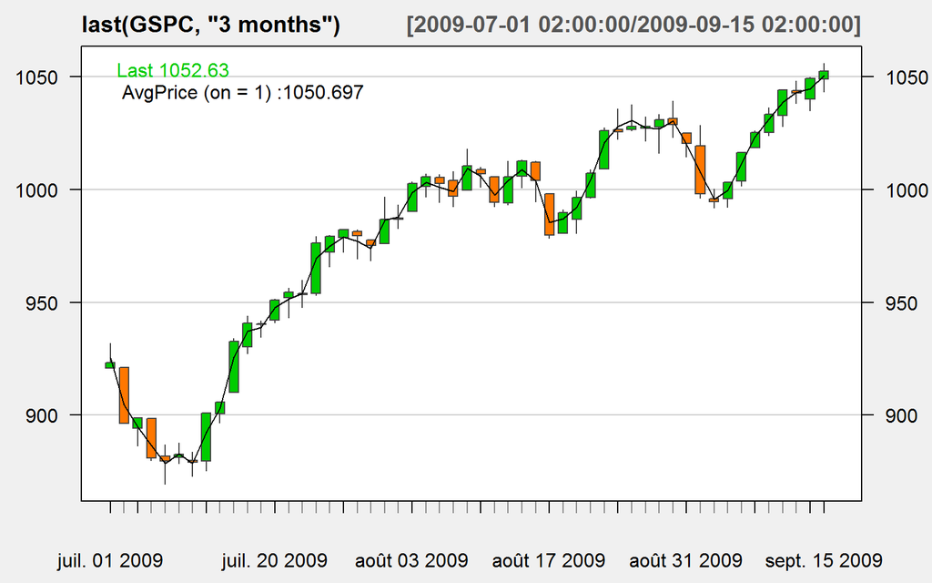

```r
avgPrice = function(p) apply(HLC(p), 1, mean)
addAvgPrice = newTA(FUN = avgPrice, col = 1, legend = "AvgPrice")
addT.ind = newTA(FUN = T.ind, col = "red", legend = "tgtRet")
get.current.chob<-function(){quantmod:::get.current.chob()}
candleChart(last(GSPC, "3 months"), theme = "white", TA = "addAvgPrice(on=1)")
```

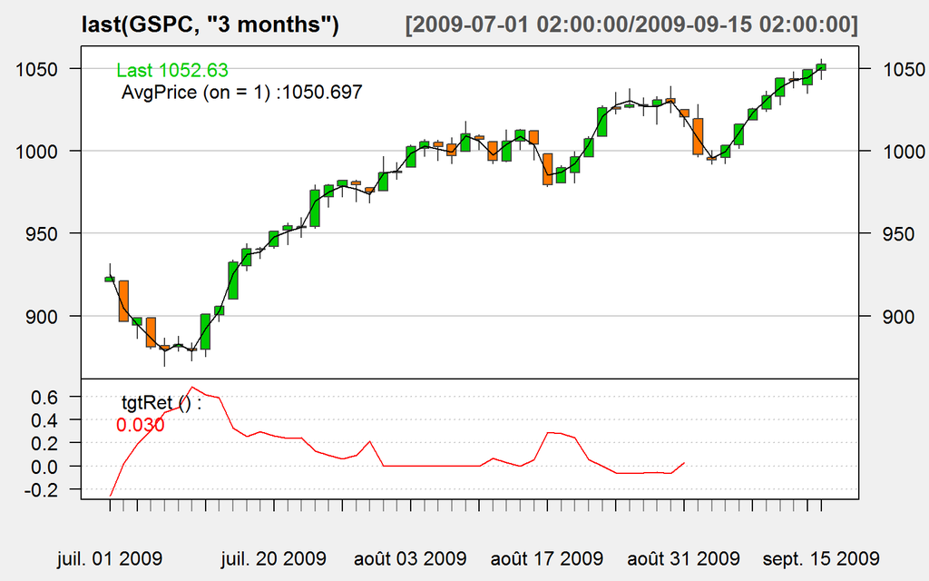

```r
candleChart(last(GSPC, "3 months"), theme = "white", TA = "addAvgPrice(on=1)")
candleChart(last(GSPC, "3 months"), theme = "white", TA = "addT.ind();addAvgPrice(on=1)")
```

```r
myATR = function(x) ATR(HLC(x))[, "atr"]
mySMI = function(x) SMI(HLC(x))[, "SMI"]
myADX = function(x) ADX(HLC(x))[, "ADX"]
myAroon = function(x) aroon(x[, c("High", "Low")])$oscillator
myBB = function(x) BBands(HLC(x))[, "pctB"]
myChaikinVol = function(x) Delt(chaikinVolatility(x[, c("High","Low")]))[, 1]
myCLV = function(x) EMA(CLV(HLC(x)))[, 1]
myEMV = function(x) EMV(x[, c("High", "Low")], x[, "Volume"])[,2]
myMACD = function(x) MACD(Cl(x))[, 2]
myMFI = function(x) MFI(x[, c("High", "Low", "Close")],x[, "Volume"])
mySAR = function(x) SAR(x[, c("High", "Close")])[, 1]
myVolat = function(x) volatility(OHLC(x), calc = "garman")[,1]
```

```r
data(GSPC)
library(randomForest)
data.model = specifyModel(T.ind(GSPC) ~ Delt(Cl(GSPC),k=1:10) +
myATR(GSPC) + mySMI(GSPC) + myADX(GSPC) + myAroon(GSPC) +
myBB(GSPC) + myChaikinVol(GSPC) + myCLV(GSPC) +
CMO(Cl(GSPC)) + EMA(Delt(Cl(GSPC))) + myEMV(GSPC) +
myVolat(GSPC) + myMACD(GSPC) + myMFI(GSPC) + RSI(Cl(GSPC)) +
mySAR(GSPC) + runMean(Cl(GSPC)) + runSD(Cl(GSPC)))
set.seed(1234)
rf = buildModel(data.model,method="randomForest",
training.per=c(start(GSPC),index(GSPC["1999-12-31"])),
ntree=50, importance=T)
```

```r
Tdata.train[,1] = trading.signals(Tdata.train[,1],0.1,-0.1)
names(Tdata.train)[1] = "signal"
summary(Tdata.train)
```

```
##  signal   Delt.Cl.GSPC.k.1.10.Delt.1.arithmetic
##  s: 904   Min.   :-0.2046693
##  h:5406   1st Qu.:-0.0044689
##  b:1232   Median : 0.0003940
##           Mean   : 0.0004208
##           3rd Qu.: 0.0053119
##           Max.   : 0.0909935
##  Delt.Cl.GSPC.k.1.10.Delt.2.arithmetic
##  Min.   :-0.2457059
##  1st Qu.:-0.0069698
##  Median : 0.0009816
##  Mean   : 0.0008499
##  3rd Qu.: 0.0086977
##  Max.   : 0.1491727
##  Delt.Cl.GSPC.k.1.10.Delt.3.arithmetic
##  Min.   :-0.263375
##  1st Qu.:-0.008611
##  Median : 0.001612
##  Mean   : 0.001275
##  3rd Qu.: 0.011162
##  Max.   : 0.104777
##  Delt.Cl.GSPC.k.1.10.Delt.4.arithmetic
##  Min.   :-0.285133
##  1st Qu.:-0.009901
##  Median : 0.002508
##  Mean   : 0.001696
##  3rd Qu.: 0.013620
##  Max.   : 0.123394
##  Delt.Cl.GSPC.k.1.10.Delt.5.arithmetic
##  Min.   :-0.273280
##  1st Qu.:-0.011109
##  Median : 0.002869
##  Mean   : 0.002115
##  3rd Qu.: 0.015413
##  Max.   : 0.141161
##  Delt.Cl.GSPC.k.1.10.Delt.6.arithmetic
##  Min.   :-0.277204
##  1st Qu.:-0.011636
##  Median : 0.003285
##  Mean   : 0.002535
```

[output cut: 43 more lines]

```
##  Max.   : 0.76098   Max.   :100.000   Max.   : 0.0154651
##    myEMV.GSPC          myVolat.GSPC      myMACD.GSPC        myMFI.GSPC
##  Min.   :-8.414e-03   Min.   :0.03746   Min.   :-6.7168   Min.   :  6.03
##  1st Qu.:-1.389e-04   1st Qu.:0.09171   1st Qu.:-0.3205   1st Qu.: 44.28
##  Median : 1.278e-05   Median :0.13929   Median : 0.3019   Median : 55.77
##  Mean   :-2.619e-05   Mean   :0.14680   Mean   : 0.2419   Mean   : 54.94
##  3rd Qu.: 1.398e-04   3rd Qu.:0.18612   3rd Qu.: 0.9034   3rd Qu.: 66.10
##  Max.   : 4.604e-03   Max.   :0.72932   Max.   : 3.2605   Max.   :100.00
##   RSI.Cl.GSPC      mySAR.GSPC      runMean.Cl.GSPC   runSD.Cl.GSPC
##  Min.   :11.36   Min.   :  62.28   Min.   :  64.37   Min.   : 0.2012
##  1st Qu.:44.56   1st Qu.: 103.89   1st Qu.: 103.73   1st Qu.: 1.1233
##  Median :54.23   Median : 173.74   Median : 175.60   Median : 1.9085
##  Mean   :53.69   Mean   : 316.28   Mean   : 316.61   Mean   : 3.6583
##  3rd Qu.:62.95   3rd Qu.: 416.10   3rd Qu.: 414.63   3rd Qu.: 3.7684
##  Max.   :85.86   Max.   :1432.92   Max.   :1447.90   Max.   :51.1432
```